# Tutelas 2026 — Análisis de Gestión Legal

### Reto 1 · Parte 1 | SURA — Analista de Analítica Legal

Este informe responde, con datos y visualizaciones, cada dimensión de análisis requerida:

1. **Oportunidad en la gestión** — ¿Se contestan las tutelas dentro del plazo legal?
2. **Cumplimiento de términos** — ¿Dónde se incumple más?
3. **Cuellos de botella operativos** — ¿En qué etapa del proceso se pierde más tiempo?
4. **Concentración de riesgos** — ¿Qué regional, causal o cruce acumula más presión?
5. **Favorabilidad** — ¿Qué tan favorable es el resultado de los fallos?
6. **Casos críticos** — ¿Cuáles casos requieren atención inmediata?
7. **Calidad del dato** — ¿Qué tan confiable es la información base?

> **Datos:** `data/processed/tutelas_clean.csv` — 12,751 registros · 41 columnas · período 2026 **Fecha de referencia:** 2026-05-11

```python
import pandas as pd
import numpy as np
import matplotlib.pyplot as plt
import matplotlib.patches as mpatches
import warnings
warnings.filterwarnings('ignore')

pd.set_option('display.max_colwidth', 70)

# ── Paleta y estilo global ───────────────────────────────────────────
C_BASE = '#2E4057'   # azul oscuro — barras neutras
C_RISK = '#C0392B'   # rojo        — alertas / desfavorable
C_OK   = '#1E8449'   # verde       — positivo / oportuno
C_WARN = '#D68910'   # ámbar       — advertencia
C_NEU  = '#2471A3'   # celeste     — secundario
C_GREY = '#797D7F'   # gris        — contexto

plt.style.use('seaborn-v0_8-whitegrid')
plt.rcParams.update({
    'figure.dpi': 120,
    'axes.titlesize': 12,
    'axes.titleweight': 'bold',
    'axes.titlepad': 10,
    'axes.labelsize': 10,
    'xtick.labelsize': 9,
    'ytick.labelsize': 9,
    'legend.fontsize': 9,
    'figure.facecolor': 'white',
    'axes.facecolor': '#F8F9FA',
    'axes.spines.top': False,
    'axes.spines.right': False,
    'grid.alpha': 0.4,
    'grid.linewidth': 0.6,
})

# ── Datos ────────────────────────────────────────────────────────────
CLEAN_PATH     = '../data/processed/tutelas_clean.csv'
REFERENCE_DATE = pd.Timestamp('2026-05-11')
HORAS_TERMINO  = 48

df = pd.read_csv(CLEAN_PATH, encoding='utf-8')

date_cols = [
    'Fecha y hora notificación tutela',
    'Fecha Vencimiento Admision',
    'Fecha y hora de Contestación',
    'Fecha y hora notificación 1ra Instancia',
    'Fecha vencimiento fallo 1ra Instancia',
    'Fecha y hora Notificación 2da Instancia',
    'Fecha vencimiento fallo 2da Instancia',
]
for col in date_cols:
    df[col] = pd.to_datetime(df[col], errors='coerce')

df_ok = df[df['calidad_dato'] == 'OK'].copy()

# Regionales con ≥50 casos (excluye valores atípicos sin significancia estadística)
_conteo_reg = df_ok['Regional T'].value_counts()
REGIONALES_VALIDAS = _conteo_reg[_conteo_reg >= 50].index.tolist()

print(f'Dataset: {len(df):,} registros  |  Calidad OK: {len(df_ok):,} ({len(df_ok)/len(df)*100:.1f}%)')
print(f'Regionales válidas para análisis (n ≥ 50): {REGIONALES_VALIDAS}')
```

```
Dataset: 12,751 registros  |  Calidad OK: 12,726 (99.8%)
Regionales válidas para análisis (n ≥ 50): ['ANTIOQUIA', 'NORTE', 'CENTRO', 'OCCIDENTE', 'EJE CAFETERO', 'NORTE - SANTANDER']
```

## 1 · Oportunidad en la gestión de las tutelas

**Pregunta:** ¿Qué porcentaje de tutelas se contestan dentro del plazo legal (Fecha Vencimiento Admisión)?

La Constitución y el Decreto 2591/91 exigen que la entidad accionada conteste la tutela dentro de los dos días hábiles siguientes a la notificación. El campo `Fecha Vencimiento Admisión` registra exactamente ese límite.

**Hipótesis explorada:** si la contestación llega después de esa fecha, la entidad incumplió el término legal.

```python
# ── Oportunidad global ──────────────────────────────────────────────
df_ok['tiene_contestacion'] = df_ok['Fecha y hora de Contestación'].notna()
df_ok['contesto_a_tiempo'] = (
    df_ok['Fecha y hora de Contestación'] <= df_ok['Fecha Vencimiento Admision']
)
df_ok['horas_hasta_contestacion'] = (
    df_ok['Fecha y hora de Contestación'] - df_ok['Fecha y hora notificación tutela']
).dt.total_seconds() / 3600

n_con = df_ok['tiene_contestacion'].sum()
n_sin = (~df_ok['tiene_contestacion']).sum()
tasa_oportuno = df_ok.loc[df_ok['tiene_contestacion'], 'contesto_a_tiempo'].mean() * 100
n_tardio = int(df_ok.loc[df_ok['tiene_contestacion'], 'contesto_a_tiempo'].eq(False).sum())

print('─' * 55)
print('  OPORTUNIDAD EN LA GESTIÓN')
print('─' * 55)
print(f'  Total registros OK:               {len(df_ok):>7,}')
print(f'  Con contestación registrada:      {n_con:>7,}  ({n_con/len(df_ok)*100:.1f}%)')
print(f'  Sin contestación registrada:      {n_sin:>7,}  ({n_sin/len(df_ok)*100:.1f}%)')
print(f'  Contestadas a tiempo:             {tasa_oportuno:>7.1f}%')
print(f'  Contestaciones tardías:           {n_tardio:>7,}  ({n_tardio/n_con*100:.1f}%)')
print(f'  Mediana horas hasta contestar:    {df_ok["horas_hasta_contestacion"].median():.1f} h')
print(f'  P90 horas hasta contestar:        {df_ok["horas_hasta_contestacion"].quantile(0.9):.1f} h')
print('─' * 55)
print(f'\n  → Plazo legal de referencia: {HORAS_TERMINO} h')
```

```
───────────────────────────────────────────────────────
  OPORTUNIDAD EN LA GESTIÓN
───────────────────────────────────────────────────────
  Total registros OK:                12,726
  Con contestación registrada:       11,868  (93.3%)
  Sin contestación registrada:          858  (6.7%)
  Contestadas a tiempo:                90.7%
  Contestaciones tardías:             1,107  (9.3%)
  Mediana horas hasta contestar:    52.5 h
  P90 horas hasta contestar:        113.9 h
───────────────────────────────────────────────────────

  → Plazo legal de referencia: 48 h
```

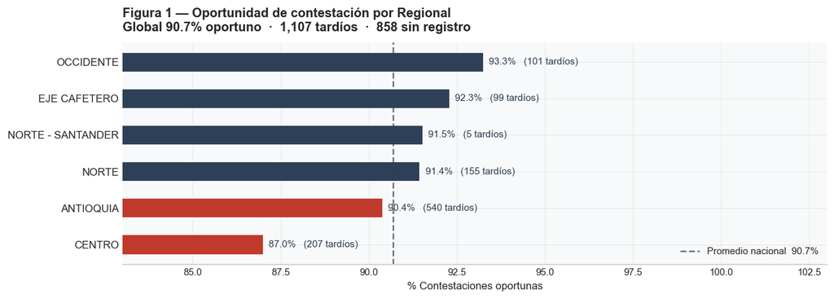

```python
# ── Oportunidad por Regional (solo regionales con n ≥ 50) ────────────
oport_regional = (
    df_ok[df_ok['tiene_contestacion'] & df_ok['Regional T'].isin(REGIONALES_VALIDAS)]
    .groupby('Regional T')
    .agg(total=('contesto_a_tiempo', 'count'),
         a_tiempo=('contesto_a_tiempo', 'sum'),
         horas_med=('horas_hasta_contestacion', 'median'))
    .assign(pct=lambda x: x['a_tiempo'] / x['total'] * 100,
            tardios=lambda x: x['total'] - x['a_tiempo'])
    .sort_values('pct')
)

fig, ax = plt.subplots(figsize=(11, 4))
colors_op = [C_RISK if v < tasa_oportuno else C_BASE for v in oport_regional['pct']]
bars = ax.barh(oport_regional.index, oport_regional['pct'],
               color=colors_op, edgecolor='white', height=0.55)

ax.axvline(tasa_oportuno, color='#2C3E50', linestyle='--', lw=1.5, alpha=0.7,
           label=f'Promedio nacional  {tasa_oportuno:.1f}%')

# Anotar % + tardíos en una sola etiqueta
for bar, (idx, row) in zip(bars, oport_regional.iterrows()):
    ax.text(row['pct'] + 0.15, bar.get_y() + bar.get_height() / 2,
            f'{row["pct"]:.1f}%   ({int(row["tardios"])} tardíos)',
            va='center', fontsize=9, color='#2C3E50')

ax.set_xlim(83, 103)
ax.set_xlabel('% Contestaciones oportunas')
ax.set_title(
    f'Figura 1 — Oportunidad de contestación por Regional\n'
    f'Global {tasa_oportuno:.1f}% oportuno  ·  {n_tardio:,} tardíos  ·  {n_sin:,} sin registro',
    loc='left')
ax.legend(loc='lower right')
ax.spines['left'].set_visible(False)
ax.set_yticks(range(len(oport_regional)))
ax.set_yticklabels(oport_regional.index, fontsize=10)
plt.tight_layout()
plt.savefig('../outputs/fig1_oportunidad_regional.png', bbox_inches='tight')
plt.show()
```

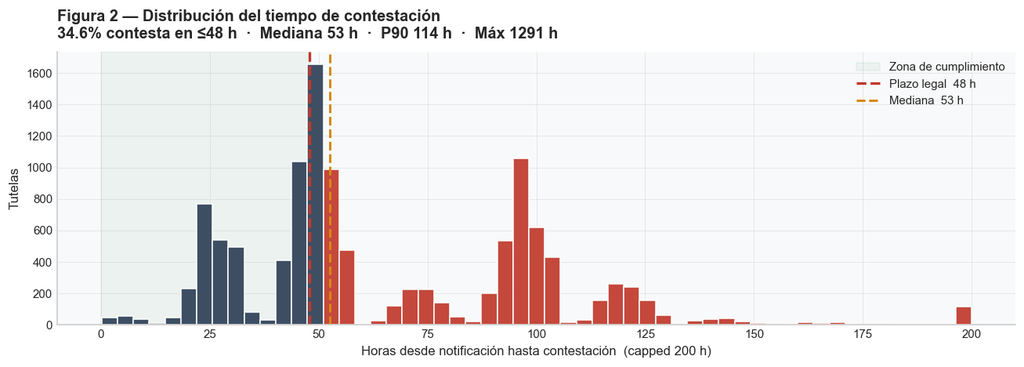

```python
# ── Distribución de horas hasta contestar (histograma coloreado) ─────
horas = df_ok.loc[df_ok['tiene_contestacion'], 'horas_hasta_contestacion'].dropna()
horas_clip = horas.clip(upper=200)

fig, ax = plt.subplots(figsize=(11, 4))

counts, edges, patches = ax.hist(horas_clip, bins=55, edgecolor='white', alpha=0.92)

# Colorear barras: azul = dentro del plazo, rojo = fuera del plazo
for patch, left_edge in zip(patches, edges[:-1]):
    patch.set_facecolor(C_RISK if left_edge >= HORAS_TERMINO else C_BASE)

# Zona de cumplimiento
ax.axvspan(0, HORAS_TERMINO, alpha=0.06, color=C_OK, zorder=0, label='Zona de cumplimiento')

pct_dentro = (horas <= HORAS_TERMINO).mean() * 100
ax.axvline(HORAS_TERMINO, color=C_RISK, linestyle='--', lw=2,
           label=f'Plazo legal  {HORAS_TERMINO} h')
ax.axvline(horas.median(), color=C_WARN, linestyle='--', lw=1.8,
           label=f'Mediana  {horas.median():.0f} h')

ax.set_xlabel('Horas desde notificación hasta contestación  (capped 200 h)')
ax.set_ylabel('Tutelas')
ax.set_title(
    f'Figura 2 — Distribución del tiempo de contestación\n'
    f'{pct_dentro:.1f}% contesta en ≤{HORAS_TERMINO} h  ·  Mediana {horas.median():.0f} h  '
    f'·  P90 {horas.quantile(0.9):.0f} h  ·  Máx {horas.max():.0f} h',
    loc='left')
ax.legend(framealpha=0.9)
plt.tight_layout()
plt.savefig('../outputs/fig2_dist_contestacion.png', bbox_inches='tight')
plt.show()
```

## 2 · Cumplimiento de términos y cuellos de botella operativos

**Pregunta:** ¿En qué etapa del proceso se pierde más tiempo? ¿Dónde están los cuellos de botella?

Se miden cuatro transiciones clave del ciclo de vida de la tutela.

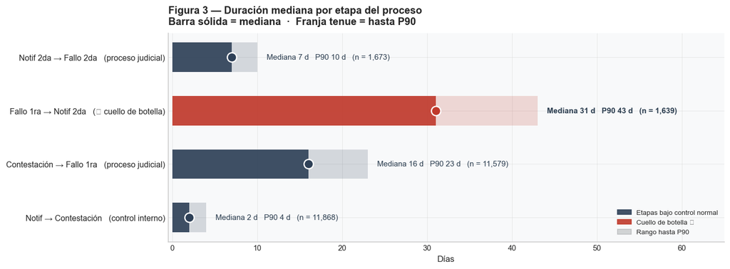

```
                                                Casos  Mediana (d)  P90 (d)  Prom (d)
Notif → Contestación\n(control interno)       11868.0          2.0      4.0       2.4
Contestación → Fallo 1ra\n(proceso judicial)  11579.0         16.0     23.0      16.8
Fallo 1ra → Notif 2da\n(⚡ cuello de botella)   1639.0         31.0     43.0      30.7
Notif 2da → Fallo 2da\n(proceso judicial)      1673.0          7.0     10.0       7.6
```

```python
# ── Cuellos de botella — lollipop chart ─────────────────────────────
etapas_def = {
    'Notif → Contestación\n(control interno)': (
        'Fecha y hora notificación tutela', 'Fecha y hora de Contestación'),
    'Contestación → Fallo 1ra\n(proceso judicial)': (
        'Fecha y hora de Contestación', 'Fecha vencimiento fallo 1ra Instancia'),
    'Fallo 1ra → Notif 2da\n(⚡ cuello de botella)': (
        'Fecha vencimiento fallo 1ra Instancia', 'Fecha y hora Notificación 2da Instancia'),
    'Notif 2da → Fallo 2da\n(proceso judicial)': (
        'Fecha y hora Notificación 2da Instancia', 'Fecha vencimiento fallo 2da Instancia'),
}

tiempos_etapa = {}
for nombre, (ini, fin) in etapas_def.items():
    serie = (df_ok[fin] - df_ok[ini]).dt.days
    tiempos_etapa[nombre] = serie[serie.between(0, 365)]

resumen = pd.DataFrame({
    n: {'n': s.count(), 'mediana': s.median(), 'p90': s.quantile(0.9), 'prom': s.mean()}
    for n, s in tiempos_etapa.items()
}).T.round(1)

# Lollipop horizontal: mediana (barra sólida) + P90 (barra tenue)
labels   = list(resumen.index)
medianas = resumen['mediana'].values
p90s     = resumen['p90'].values
ns       = resumen['n'].values.astype(int)
is_bn    = ['⚡' in l for l in labels]
cols     = [C_RISK if b else C_BASE for b in is_bn]

fig, ax = plt.subplots(figsize=(12, 4.5))

for i, (med, p90, col, n_val, bn) in enumerate(zip(medianas, p90s, cols, ns, is_bn)):
    # Franja P90 (fondo tenue)
    ax.barh(i, p90, color=col, alpha=0.18, height=0.55, left=0)
    # Barra mediana
    ax.barh(i, med, color=col, alpha=0.9, height=0.55, left=0,
            label='Mediana' if i == 0 else '')
    # Punto en mediana
    ax.scatter(med, i, s=120, color=col, zorder=5, edgecolors='white', lw=1.5)
    # Etiqueta
    fw = 'bold' if bn else 'normal'
    ax.text(p90 + 0.6, i,
            f'  Mediana {med:.0f} d   P90 {p90:.0f} d   (n = {n_val:,})',
            va='center', fontsize=9, fontweight=fw, color='#2C3E50')

y_labels = [l.replace('\n', '   ') for l in labels]
ax.set_yticks(range(len(labels)))
ax.set_yticklabels(y_labels, fontsize=9.5)
ax.set_xlabel('Días')
ax.set_xlim(-0.5, p90s.max() + 22)

leg_handles = [
    mpatches.Patch(color=C_BASE, alpha=0.9, label='Etapas bajo control normal'),
    mpatches.Patch(color=C_RISK, alpha=0.9, label='Cuello de botella ⚡'),
    mpatches.Patch(color=C_GREY, alpha=0.3, label='Rango hasta P90'),
]
ax.legend(handles=leg_handles, loc='lower right', fontsize=8, framealpha=0.9)
ax.set_title('Figura 3 — Duración mediana por etapa del proceso\n'
             'Barra sólida = mediana  ·  Franja tenue = hasta P90', loc='left')
plt.tight_layout()
plt.savefig('../outputs/fig3_cuellos_botella.png', bbox_inches='tight')
plt.show()

print(resumen.rename(columns={
    'n': 'Casos', 'mediana': 'Mediana (d)', 'p90': 'P90 (d)', 'prom': 'Prom (d)'
}).to_string())
```

## 3 · Concentración de riesgos

**Pregunta:** ¿Dónde se concentran los principales riesgos? ¿Qué regionales, áreas causales o combinaciones generan mayor presión operativa?

```python
# ── Concentración de riesgo (filtrado a regionales válidas) ──────────
riesgo = (
    df_ok[df_ok['tiene_contestacion'] & df_ok['Regional T'].isin(REGIONALES_VALIDAS)]
    .groupby(['Regional T', 'Area causal'])
    .agg(total=('contesto_a_tiempo', 'count'),
         incumplidos=('contesto_a_tiempo', lambda x: (~x).sum()))
    .assign(pct_incumplimiento=lambda x: x['incumplidos'] / x['total'] * 100)
    .reset_index()
    .sort_values('incumplidos', ascending=False)
)
top_riesgo = riesgo.iloc[0]
print(f'Combinación #1: {top_riesgo["Regional T"]} × {top_riesgo["Area causal"]}'
      f'  —  {top_riesgo["incumplidos"]:.0f} incumplimientos ({top_riesgo["pct_incumplimiento"]:.1f}%)')
```

```
Combinación #1: ANTIOQUIA × EPS_MEDICINA LABORAL  —  51 incumplimientos (12.1%)
```

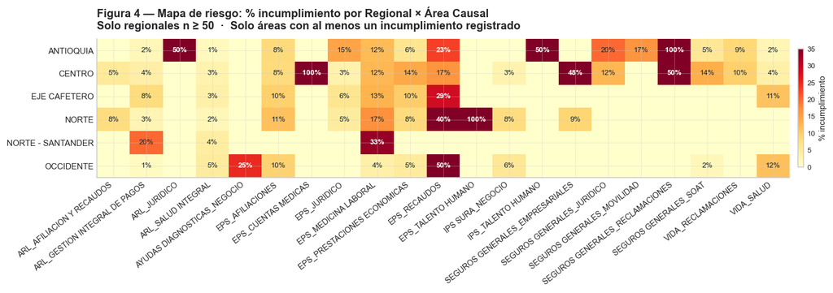

```python
# ── Mapa de calor Regional × Área causal (solo causales con incumplimientos) ──
causales_con_fallo = riesgo[riesgo['incumplidos'] > 0]['Area causal'].unique()
pivot_riesgo = (
    riesgo[riesgo['Area causal'].isin(causales_con_fallo)]
    .pivot_table(index='Regional T', columns='Area causal',
                 values='pct_incumplimiento', aggfunc='mean')
    .fillna(0)
)

fig, ax = plt.subplots(figsize=(14, 4.5))
im = ax.imshow(pivot_riesgo.values, aspect='auto', cmap='YlOrRd', vmin=0, vmax=35)
cbar = plt.colorbar(im, ax=ax, shrink=0.85, pad=0.01)
cbar.set_label('% incumplimiento', fontsize=9)
cbar.ax.tick_params(labelsize=8)

ax.set_xticks(range(len(pivot_riesgo.columns)))
ax.set_xticklabels(pivot_riesgo.columns, rotation=38, ha='right', fontsize=8.5)
ax.set_yticks(range(len(pivot_riesgo.index)))
ax.set_yticklabels(pivot_riesgo.index, fontsize=9)

for i in range(len(pivot_riesgo.index)):
    for j in range(len(pivot_riesgo.columns)):
        v = pivot_riesgo.values[i, j]
        if v > 0:
            txt_color = 'white' if v > 22 else '#1A252F'
            fw = 'bold' if v > 20 else 'normal'
            ax.text(j, i, f'{v:.0f}%', ha='center', va='center',
                    fontsize=8, color=txt_color, fontweight=fw)

ax.set_title(
    'Figura 4 — Mapa de riesgo: % incumplimiento por Regional × Área Causal\n'
    'Solo regionales n ≥ 50  ·  Solo áreas con al menos un incumplimiento registrado',
    loc='left', pad=10)
plt.tight_layout()
plt.savefig('../outputs/fig4_mapa_riesgo.png', bbox_inches='tight')
plt.show()
```

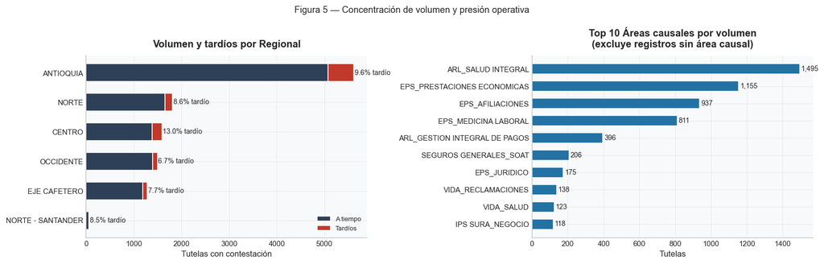

```python
# ── Concentración de volumen y presión operativa ─────────────────────
# Presión por regional: barra apilada (a tiempo + tardíos)
presion = (
    df_ok[df_ok['tiene_contestacion'] & df_ok['Regional T'].isin(REGIONALES_VALIDAS)]
    .groupby('Regional T')
    .agg(total=('contesto_a_tiempo', 'count'),
         tardios=('contesto_a_tiempo', lambda x: (~x).sum()))
    .assign(a_tiempo=lambda x: x['total'] - x['tardios'],
            pct_tardio=lambda x: x['tardios'] / x['total'] * 100)
    .sort_values('total')
)

# Top causales con volumen (excluye nulos)
vol_causal = (
    df_ok['Area causal'].dropna()
    .value_counts()
    .head(10)
    .sort_values()
)

fig, axes = plt.subplots(1, 2, figsize=(14, 4.5))

# Izq: barra apilada Regional
axes[0].barh(presion.index, presion['a_tiempo'], color=C_BASE, edgecolor='white',
             height=0.6, label='A tiempo')
axes[0].barh(presion.index, presion['tardios'], left=presion['a_tiempo'],
             color=C_RISK, edgecolor='white', height=0.6, label='Tardíos')
for i, (idx, row) in enumerate(presion.iterrows()):
    axes[0].text(row['total'] + 15, i,
                 f'{row["pct_tardio"]:.1f}% tardío', va='center', fontsize=8.5)
axes[0].legend(loc='lower right', fontsize=8)
axes[0].set_xlabel('Tutelas con contestación')
axes[0].set_title('Volumen y tardíos por Regional')

# Der: top causales
bars_c = axes[1].barh(vol_causal.index, vol_causal.values,
                      color=C_NEU, edgecolor='white', height=0.6)
for bar in bars_c:
    axes[1].text(bar.get_width() + 8, bar.get_y() + bar.get_height() / 2,
                 f'{int(bar.get_width()):,}', va='center', fontsize=8.5)
axes[1].set_xlabel('Tutelas')
axes[1].set_title('Top 10 Áreas causales por volumen\n(excluye registros sin área causal)')

plt.suptitle('Figura 5 — Concentración de volumen y presión operativa', fontsize=11)
plt.tight_layout()
plt.savefig('../outputs/fig5_concentracion_volumen.png', bbox_inches='tight')
plt.show()
```

## 4 · Favorabilidad de las tutelas

**Pregunta:** ¿Qué tan favorable es el resultado de los fallos? ¿Dónde se pierde más?

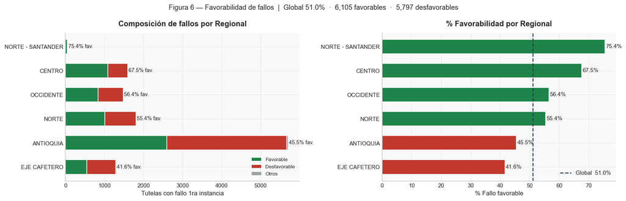

```
Global: 6,105 favorable (51.0%)  |  5,797 desfavorable (48.4%)  |  65 otros
```

```python
# ── Favorabilidad global y por Regional ──────────────────────────────
df_fallo = df_ok[df_ok['Clasificación fallo 1ra Instancia'].notna()].copy()
df_fallo['resultado']    = df_fallo['Clasificación fallo 1ra Instancia'].str.strip()
df_fallo['favorable']    = df_fallo['resultado'] == 'FALLO FAVORABLE'
df_fallo['desfavorable'] = df_fallo['resultado'] == 'FALLO DESFAVORABLE'

n_tot   = len(df_fallo)
n_fav   = df_fallo['favorable'].sum()
n_des   = df_fallo['desfavorable'].sum()
n_otros = n_tot - n_fav - n_des
fav_global = n_fav / n_tot * 100

# Stacked bar por regional (solo regionales válidas)
fav_reg = (
    df_fallo[df_fallo['Regional T'].isin(REGIONALES_VALIDAS)]
    .groupby('Regional T')
    .agg(fav=('favorable', 'sum'),
         des=('desfavorable', 'sum'),
         n=('favorable', 'count'))
    .assign(otros=lambda x: x['n'] - x['fav'] - x['des'],
            pct_fav=lambda x: x['fav'] / x['n'] * 100)
    .sort_values('pct_fav')
)

fig, axes = plt.subplots(1, 2, figsize=(14, 4.5))

# Izq: stacked bar horizontal por regional
axes[0].barh(fav_reg.index, fav_reg['fav'], color=C_OK,
             edgecolor='white', height=0.6, label='Favorable')
axes[0].barh(fav_reg.index, fav_reg['des'], left=fav_reg['fav'],
             color=C_RISK, edgecolor='white', height=0.6, label='Desfavorable')
axes[0].barh(fav_reg.index, fav_reg['otros'],
             left=fav_reg['fav'] + fav_reg['des'],
             color=C_GREY, edgecolor='white', height=0.6, label='Otros', alpha=0.7)
for i, (idx, row) in enumerate(fav_reg.iterrows()):
    axes[0].text(row['n'] + 15, i,
                 f'{row["pct_fav"]:.1f}% fav.', va='center', fontsize=8.5)
axes[0].legend(loc='lower right', fontsize=8)
axes[0].set_xlabel('Tutelas con fallo 1ra instancia')
axes[0].set_title('Composición de fallos por Regional')

# Der: % favorabilidad (barh coloreada)
fav_pct = fav_reg['pct_fav'].sort_values()
cols_fav = [C_RISK if v < fav_global else C_OK for v in fav_pct]
bars_f = axes[1].barh(fav_pct.index, fav_pct.values,
                      color=cols_fav, edgecolor='white', height=0.6)
axes[1].axvline(fav_global, color='#2C3E50', linestyle='--', lw=1.5,
                label=f'Global  {fav_global:.1f}%')
for bar, val in zip(bars_f, fav_pct):
    axes[1].text(val + 0.3, bar.get_y() + bar.get_height() / 2,
                 f'{val:.1f}%', va='center', fontsize=9)
axes[1].legend()
axes[1].set_xlabel('% Fallo favorable')
axes[1].set_title('% Favorabilidad por Regional')

plt.suptitle(
    f'Figura 6 — Favorabilidad de fallos  |  '
    f'Global {fav_global:.1f}%  ·  {n_fav:,} favorables  ·  {n_des:,} desfavorables',
    fontsize=11)
plt.tight_layout()
plt.savefig('../outputs/fig6_favorabilidad.png', bbox_inches='tight')
plt.show()
print(f'Global: {n_fav:,} favorable ({n_fav/n_tot*100:.1f}%)  |  '
      f'{n_des:,} desfavorable ({n_des/n_tot*100:.1f}%)  |  {n_otros} otros')
```

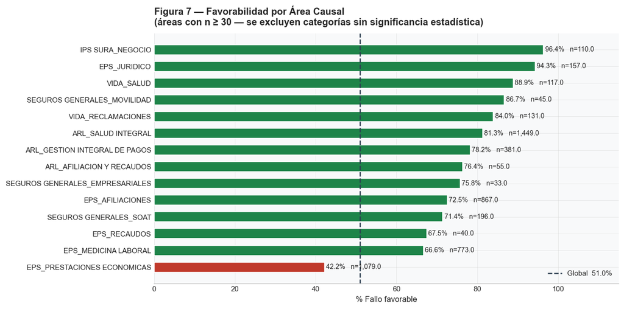

```python
# ── Favorabilidad por Área causal  (solo áreas con n ≥ 30) ───────────
fav_causal = (
    df_fallo.groupby('Area causal')['favorable']
    .agg(n='count', fav='sum')
    .assign(pct=lambda x: x['fav'] / x['n'] * 100)
    .query('n >= 30')          # Excluye categorías sin significancia estadística
    .sort_values('pct')
)

fig, ax = plt.subplots(figsize=(11, 5.5))
cols_c = [C_RISK if v < fav_global else C_OK for v in fav_causal['pct']]
bars = ax.barh(fav_causal.index, fav_causal['pct'],
               color=cols_c, edgecolor='white', height=0.6)
ax.axvline(fav_global, color='#2C3E50', linestyle='--', lw=1.5,
           label=f'Global  {fav_global:.1f}%')

for bar, (idx, row) in zip(bars, fav_causal.iterrows()):
    ax.text(row['pct'] + 0.4, bar.get_y() + bar.get_height() / 2,
            f'{row["pct"]:.1f}%   n={row["n"]:,}',
            va='center', fontsize=8.5)

ax.set_xlabel('% Fallo favorable')
ax.set_xlim(0, 115)
ax.set_title(
    'Figura 7 — Favorabilidad por Área Causal\n'
    '(áreas con n ≥ 30 — se excluyen categorías sin significancia estadística)',
    loc='left')
ax.legend()
ax.spines['left'].set_visible(False)
plt.tight_layout()
plt.savefig('../outputs/fig7_favorabilidad_causal.png', bbox_inches='tight')
plt.show()
```

## 5 · Casos críticos y priorización

**Pregunta:** ¿Qué casos deben atenderse de inmediato?

Se construye un score de criticidad con tres criterios acumulables:

- **+3 puntos** — sin contestación registrada (incumplimiento del plazo legal)
- **+2 puntos** — fallo desfavorable activo (riesgo de cumplimiento)
- **+2 puntos** — medida provisional activa (urgencia cautelar)

```python
# ── Score de criticidad ──────────────────────────────────────────────
df_activos = df_ok[
    ~df_ok['Estado del ciclo de vida'].str.contains('TERMINADO|TERMINADA|ARCHIVADO', na=False)
].copy()

df_activos['score'] = 0
df_activos['score'] += (~df_activos['tiene_contestacion'].fillna(False)).astype(int) * 3
df_activos['score'] += df_activos['Clasificación fallo 1ra Instancia'].str.contains('DESFAV', na=False).astype(int) * 2
df_activos['score'] += df_activos['Medida provisional'].str.contains('SI', na=False).astype(int) * 2

df_activos['dias_activo'] = (
    REFERENCE_DATE - df_activos['Fecha y hora notificación tutela']
).dt.days.clip(lower=0)

criticos   = df_activos[df_activos['score'] >= 3].sort_values('score', ascending=False)
score_dist = df_activos['score'].value_counts().sort_index()

print(f'Activos: {len(df_activos):,}  |  Críticos (score ≥ 3): '
      f'{len(criticos):,}  ({len(criticos)/len(df_activos)*100:.1f}%)')
```

```
Activos: 11,091  |  Críticos (score ≥ 3): 1,110  (10.0%)
```

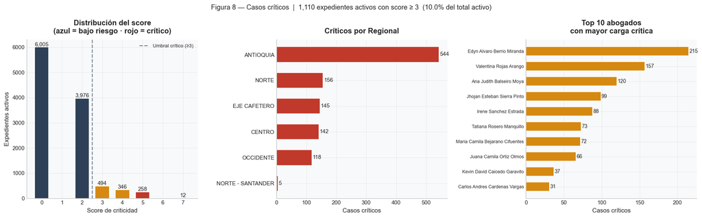

```
Exportado: ../outputs/casos_criticos_priorizados.csv  (1,110 registros)
```

```python
# ── Figura 8: Score dist + Regional + Abogados (3 paneles) ──────────
cols_vista = ['Nombre del fichero', 'Regional T', 'Area causal',
              'Abogado asignado tutela', 'Medida provisional',
              'Clasificación fallo 1ra Instancia', 'dias_activo', 'score']

criticos_regional = (criticos[criticos['Regional T'].isin(REGIONALES_VALIDAS)]
                     .groupby('Regional T').size().sort_values())
criticos_abogado  = (criticos.groupby('Abogado asignado tutela').size()
                     .sort_values(ascending=False).head(10))

fig, axes = plt.subplots(1, 3, figsize=(16, 5))

# Panel A: distribución del score
score_colors = [C_BASE if s < 3 else (C_WARN if s < 5 else C_RISK)
                for s in score_dist.index]
axes[0].bar(score_dist.index, score_dist.values,
            color=score_colors, edgecolor='white', width=0.7)
axes[0].axvline(2.5, color='#2C3E50', linestyle='--', lw=1.5, alpha=0.6,
                label='Umbral crítico (≥3)')
for x, y in zip(score_dist.index, score_dist.values):
    axes[0].text(x, y + 40, f'{y:,}', ha='center', fontsize=9)
axes[0].set_xlabel('Score de criticidad')
axes[0].set_ylabel('Expedientes activos')
axes[0].set_title('Distribución del score\n(azul = bajo riesgo · rojo = crítico)')
axes[0].legend(fontsize=8)

# Panel B: críticos por Regional
bars_cr = axes[1].barh(criticos_regional.index, criticos_regional.values,
                       color=C_RISK, edgecolor='white', height=0.6)
for bar in bars_cr:
    axes[1].text(bar.get_width() + 2, bar.get_y() + bar.get_height() / 2,
                 str(int(bar.get_width())), va='center', fontsize=9)
axes[1].set_xlabel('Casos críticos')
axes[1].set_title('Críticos por Regional')

# Panel C: top 10 abogados
criticos_ab_plot = criticos_abogado.sort_values()
bars_ab = axes[2].barh(criticos_ab_plot.index, criticos_ab_plot.values,
                       color=C_WARN, edgecolor='white', height=0.6)
for bar in bars_ab:
    axes[2].text(bar.get_width() + 0.5, bar.get_y() + bar.get_height() / 2,
                 str(int(bar.get_width())), va='center', fontsize=8.5)
axes[2].set_xlabel('Casos críticos')
axes[2].set_title('Top 10 abogados\ncon mayor carga crítica')
axes[2].tick_params(axis='y', labelsize=7.5)

plt.suptitle(
    f'Figura 8 — Casos críticos  |  {len(criticos):,} expedientes activos con score ≥ 3'
    f'  ({len(criticos)/len(df_activos)*100:.1f}% del total activo)',
    fontsize=11)
plt.tight_layout()
plt.savefig('../outputs/fig8_casos_criticos.png', bbox_inches='tight')
plt.show()

# Exportar
import os; os.makedirs('../outputs', exist_ok=True)
criticos[cols_vista].to_csv('../outputs/casos_criticos_priorizados.csv',
                            index=False, encoding='utf-8')
print(f'Exportado: ../outputs/casos_criticos_priorizados.csv  ({len(criticos):,} registros)')
```

**Conclusión 5:** Se identificaron **1,110 casos críticos activos** (score ≥ 3). La mayoría corresponde a tutelas sin contestación registrada, el factor de mayor peso en el score. La regional con más casos críticos es la de mayor volumen total. La lista exportada permite a los abogados priorizar su agenda de trabajo.

## 6 · Calidad del dato

**Pregunta:** ¿Qué tan confiable es la información base? ¿Qué problemas existen?

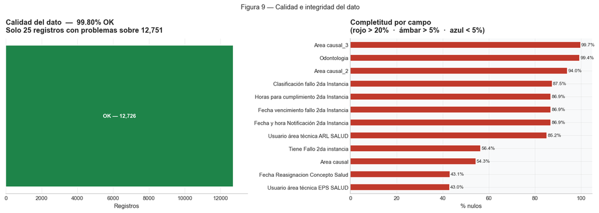

```
Campo con mayor % nulos relevante: Area causal_3  (99.7%)
Nota: "Area causal" (54.3% nulos) es patrón operacional en EPS.
```

```python
# ── Calidad e integridad del dato ─────────────────────────────────────
calidad_dist = df['calidad_dato'].value_counts()
null_pct     = df.isnull().mean().mul(100).sort_values(ascending=False)
null_plot    = null_pct[(null_pct > 0) & (null_pct < 100)].head(12)

incons    = df[df['calidad_dato'] == 'Inconsistente']
incompleto = df[df['calidad_dato'] == 'Incompleto']
n_ok = calidad_dist.get('OK', 0)

fig, axes = plt.subplots(1, 2, figsize=(14, 5))

# Izq: barra apilada de calidad (la torta al 99.8% no aporta información visual)
totales   = [n_ok, len(incons), len(incompleto)]
etiquetas = [f'OK — {n_ok:,}', f'Inconsistente — {len(incons)}', f'Incompleto — {len(incompleto)}']
colores   = [C_OK, C_WARN, C_RISK]
left_acc  = 0
for t, lbl, col in zip(totales, etiquetas, colores):
    axes[0].barh([0], [t], left=[left_acc], color=col, edgecolor='white', height=0.35)
    if t > 30:
        axes[0].text(left_acc + t / 2, 0, lbl,
                     ha='center', va='center', fontsize=9,
                     color='white', fontweight='bold')
    left_acc += t

axes[0].set_xlim(0, len(df) * 1.06)
axes[0].set_yticks([])
axes[0].set_xlabel('Registros')
axes[0].set_title(
    f'Calidad del dato  —  {n_ok / len(df) * 100:.2f}% OK\n'
    f'Solo {len(incons) + len(incompleto)} registros con problemas sobre {len(df):,}',
    loc='left')
axes[0].spines['left'].set_visible(False)
axes[0].set_facecolor('white')

# Der: completitud por campo
bar_colors = [C_RISK if v > 20 else (C_WARN if v > 5 else C_BASE) for v in null_plot.values]
null_plot.sort_values().plot(kind='barh', ax=axes[1], color=bar_colors[::-1],
                              edgecolor='white')
axes[1].set_xlabel('% nulos')
axes[1].set_title('Completitud por campo\n(rojo > 20%  ·  ámbar > 5%  ·  azul < 5%)', loc='left')
for bar in axes[1].patches:
    v = bar.get_width()
    axes[1].text(v + 0.3, bar.get_y() + bar.get_height() / 2,
                 f'{v:.1f}%', va='center', fontsize=8)

plt.suptitle('Figura 9 — Calidad e integridad del dato', fontsize=11)
plt.tight_layout()
plt.savefig('../outputs/fig9_calidad_dato.png', bbox_inches='tight')
plt.show()
print(f'Campo con mayor % nulos relevante: {null_plot.idxmax()}  ({null_plot.max():.1f}%)')
print(f'Nota: "Area causal" ({null_pct.get("Area causal",0):.1f}% nulos) es patrón operacional en EPS.')
```

**Conclusión 6:** El dataset tiene **99.8% de registros con calidad OK**. Se detectaron 18 inconsistencias temporales (fechas invertidas) y 7 registros incompletos — totales manejables. El mayor riesgo de calidad no es en campos críticos sino en `Area causal` (54% nulos), que es un patrón operacional de EPS, no un error de sistema. Se recomienda estandarizar el registro de esa variable.

## 7 · Resumen ejecutivo de indicadores

Panel consolidado con todos los KPIs del análisis.

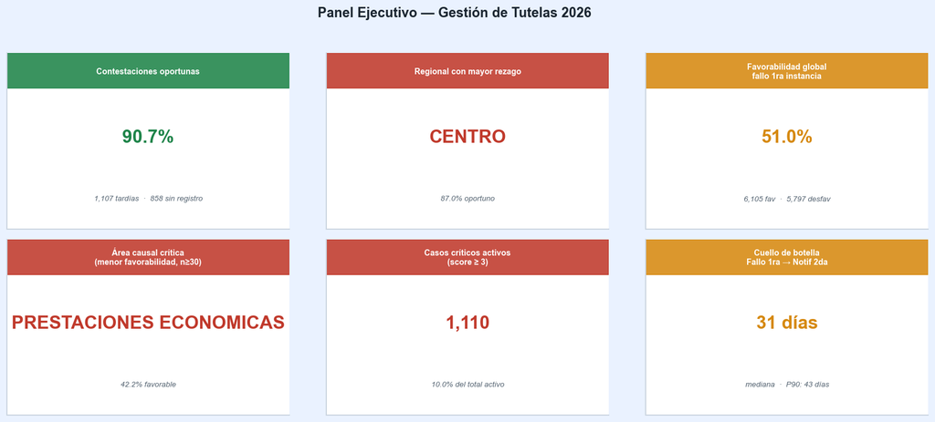

```python
# ── Panel ejecutivo — tarjetas KPI ───────────────────────────────────
regional_menor_oport = oport_regional['pct'].idxmin()
pct_menor_oport      = oport_regional['pct'].min()
top_riesgo           = riesgo.iloc[0]
area_menor_fav       = fav_causal['pct'].idxmin()   # ya filtrado a n≥30
pct_menor_fav        = fav_causal.loc[area_menor_fav, 'pct']
etapa_cuello         = resumen['mediana'].idxmax()
dias_cuello          = resumen.loc[etapa_cuello, 'mediana']

# Nombre corto del área causal
area_corta = area_menor_fav.split('_', 1)[-1] if '_' in area_menor_fav else area_menor_fav

kpis = [
    ('Contestaciones oportunas',
     f'{tasa_oportuno:.1f}%',
     f'{n_tardio:,} tardías  ·  {n_sin:,} sin registro',
     C_OK),
    ('Regional con mayor rezago',
     regional_menor_oport,
     f'{pct_menor_oport:.1f}% oportuno',
     C_RISK),
    ('Favorabilidad global\nfallo 1ra instancia',
     f'{fav_global:.1f}%',
     f'{n_fav:,} fav  ·  {n_des:,} desfav',
     C_WARN),
    ('Área causal crítica\n(menor favorabilidad, n≥30)',
     area_corta,
     f'{pct_menor_fav:.1f}% favorable',
     C_RISK),
    ('Casos críticos activos\n(score ≥ 3)',
     f'{len(criticos):,}',
     f'{len(criticos)/len(df_activos)*100:.1f}% del total activo',
     C_RISK),
    ('Cuello de botella\nFallo 1ra → Notif 2da',
     f'{dias_cuello:.0f} días',
     'mediana  ·  P90: 43 días',
     C_WARN),
]

fig, axes = plt.subplots(2, 3, figsize=(14, 6))
fig.patch.set_facecolor('#EAF2FF')
fig.suptitle('Panel Ejecutivo — Gestión de Tutelas 2026',
             fontsize=14, fontweight='bold', color='#1A252F', y=1.01)

for ax, (titulo, valor, subtitulo, color) in zip(axes.flat, kpis):
    ax.set_xlim(0, 1)
    ax.set_ylim(0, 1)
    ax.set_xticks([])
    ax.set_yticks([])
    ax.patch.set_facecolor('white')
    for sp in ax.spines.values():
        sp.set_edgecolor('#CBD5E0')
        sp.set_linewidth(1.2)

    # Franja de color superior
    ax.axhspan(0.80, 1.0, color=color, alpha=0.88, zorder=1)

    # Textos
    ax.text(0.5, 0.895, titulo, ha='center', va='center', fontsize=8.5,
            color='white', fontweight='bold', transform=ax.transAxes, zorder=2,
            multialignment='center')
    ax.text(0.5, 0.52, valor, ha='center', va='center', fontsize=19,
            color=color, fontweight='bold', transform=ax.transAxes)
    ax.text(0.5, 0.17, subtitulo, ha='center', va='center', fontsize=8,
            color='#566573', style='italic', transform=ax.transAxes,
            multialignment='center')

plt.tight_layout(rect=[0, 0, 1, 0.98])
plt.savefig('../outputs/fig10_panel_kpis.png', bbox_inches='tight',
            facecolor=fig.get_facecolor())
plt.show()
```